# level 2 - Project 2 - Dataset - [Link](https://www.kaggle.com/datasets/yasserh/wine-quality-dataset)

## 5. Model Building

```python
# Train-Test Split
X_train, X_test, y_train, y_test = train_test_split(X_scaled, y, test_size=0.2, random_state=42)
```

```python
# Model Training and Evaluation
models = {
    "Random Forest": RandomForestClassifier(),
    "SGD Classifier": SGDClassifier(),
    "SVC": SVC()
}
```

```
Random Forest - Accuracy: 0.7030567685589519
Random Forest - Precision: 0.6772052401746724
Random Forest - Recall: 0.7030567685589519
Random Forest - F1 Score: 0.6894566468965218
              precision    recall  f1-score   support

           4       0.00      0.00      0.00         6
           5       0.73      0.80      0.77        96
           6       0.68      0.68      0.68        99
           7       0.68      0.65      0.67        26
           8       0.00      0.00      0.00         2

    accuracy                           0.70       229
   macro avg       0.42      0.43      0.42       229
weighted avg       0.68      0.70      0.69       229
```

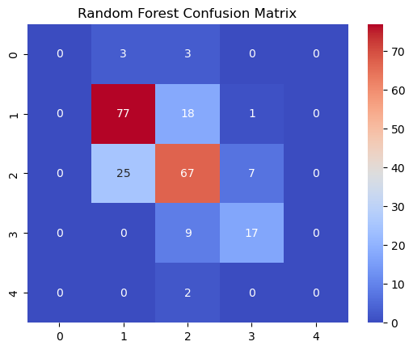

```
SGD Classifier - Accuracy: 0.519650655021834
SGD Classifier - Precision: 0.5047292871908126
SGD Classifier - Recall: 0.519650655021834
SGD Classifier - F1 Score: 0.5120282092822296
              precision    recall  f1-score   support

           3       0.00      0.00      0.00         0
           4       0.00      0.00      0.00         6
           5       0.59      0.60      0.59        96
           6       0.50      0.53      0.51        99
           7       0.36      0.35      0.35        26
           8       0.00      0.00      0.00         2

    accuracy                           0.52       229
   macro avg       0.24      0.25      0.24       229
weighted avg       0.50      0.52      0.51       229
```

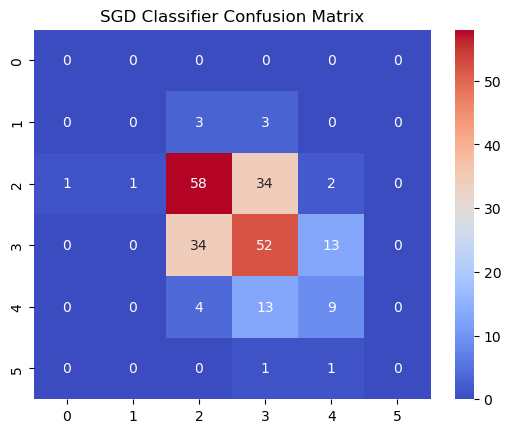

```
SVC - Accuracy: 0.6375545851528385
SVC - Precision: 0.6114597334045156
SVC - Recall: 0.6375545851528385
SVC - F1 Score: 0.6176733219517373
              precision    recall  f1-score   support

           4       0.00      0.00      0.00         6
           5       0.70      0.74      0.72        96
           6       0.59      0.69      0.64        99
           7       0.54      0.27      0.36        26
           8       0.00      0.00      0.00         2

    accuracy                           0.64       229
   macro avg       0.37      0.34      0.34       229
weighted avg       0.61      0.64      0.62       229
```

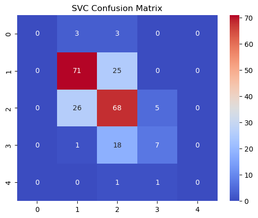

```python
for name, model in models.items():
    model.fit(X_train, y_train)
    y_pred = model.predict(X_test)
    print(f"{name} - Accuracy: {accuracy_score(y_test, y_pred)}")
    print(f"{name} - Precision: {precision_score(y_test, y_pred, average = 'weighted')}")
    print(f"{name} - Recall: {recall_score(y_test, y_pred, average = 'weighted')}")
    print(f"{name} - F1 Score: {f1_score(y_test, y_pred, average = 'weighted')}")
    print(classification_report(y_test, y_pred))
    sns.heatmap(confusion_matrix(y_test, y_pred), annot=True, fmt="d", cmap="coolwarm")
    plt.title(f"{name} Confusion Matrix")
    plt.show()
```

## 6. Cross Validation

```python
from sklearn.model_selection import cross_val_score

# Cross-validation (5-fold) for each model
for name, model in models.items():
    cv_scores = cross_val_score(model, X_scaled, y, cv=5, scoring='accuracy')
    print(f"{name} Cross-Validation Accuracy: {cv_scores.mean():.4f} ± {cv_scores.std():.4f}")
```

```
Random Forest Cross-Validation Accuracy: 0.5792 ± 0.0166
SGD Classifier Cross-Validation Accuracy: 0.5416 ± 0.0591
SVC Cross-Validation Accuracy: 0.6002 ± 0.0353
```

### 7. HyperParameter Tuning

### 7.1 Random Forest

```python
from sklearn.model_selection import GridSearchCV

rf_params = {
    'n_estimators': [50, 100, 200],
    'max_depth': [None, 10, 20, 30],
    'min_samples_split': [2, 5, 10]
}

rf_grid_search = GridSearchCV(RandomForestClassifier(), rf_params, cv=5, scoring='accuracy')
rf_grid_search.fit(X_train, y_train)

print("Best parameters for Random Forest:", rf_grid_search.best_params_)
print("Best cross-validation accuracy for Random Forest:", rf_grid_search.best_score_)
```

```
Best parameters for Random Forest: {'max_depth': 10, 'min_samples_split': 2, 'n_estimators': 200}
Best cross-validation accuracy for Random Forest: 0.6531015432654776
```

### 7.2 Stochastic Gradient Descent (SGD)

```python
sgd_params = {
    'loss': ['hinge', 'log'],
    'penalty': ['l2', 'l1', 'elasticnet'],
    'alpha': [0.0001, 0.001, 0.01]
}

sgd_grid_search = GridSearchCV(SGDClassifier(), sgd_params, cv=5, scoring='accuracy')
sgd_grid_search.fit(X_train, y_train)

print("Best parameters for SGD:", sgd_grid_search.best_params_)
print("Best cross-validation accuracy for SGD:", sgd_grid_search.best_score_)
```

```
Best parameters for SGD: {'alpha': 0.001, 'loss': 'hinge', 'penalty': 'l1'}
Best cross-validation accuracy for SGD: 0.5678556416261334
```

### 7.3 Support Vector Classifier (SVC)

```python
svc_params = {
    'C': [0.1, 1, 10],
    'kernel': ['linear', 'rbf', 'poly'],
    'gamma': ['scale', 'auto']
}

svc_grid_search = GridSearchCV(SVC(), svc_params, cv=5, scoring='accuracy')
svc_grid_search.fit(X_train, y_train)

print("Best parameters for SVC:", svc_grid_search.best_params_)
print("Best cross-validation accuracy for SVC:", svc_grid_search.best_score_)
```

```
Best parameters for SVC: {'C': 1, 'gamma': 'scale', 'kernel': 'rbf'}
Best cross-validation accuracy for SVC: 0.6170059448747974
```

### 8. Results, Interpretation and Visualization

### 8.1 Feature Importance(Randome Forest):

```python
# Retrieve feature importances from the best Random Forest model
best_rf_model = rf_grid_search.best_estimator_
feature_importances = best_rf_model.feature_importances_
```

```python
# Create a DataFrame for visualization
importance_df = pd.DataFrame({
    'Feature': X.columns,
    'Importance': feature_importances
}).sort_values(by='Importance', ascending=False)
```

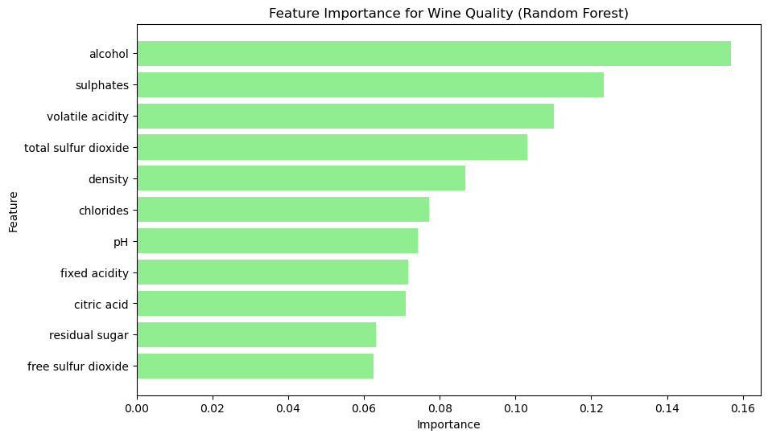

```python
# Plot feature importances
plt.figure(figsize=(10, 6))
plt.barh(importance_df['Feature'], importance_df['Importance'],color='LightGreen')
plt.xlabel('Importance')
plt.ylabel('Feature')
plt.title('Feature Importance for Wine Quality (Random Forest)')
plt.gca().invert_yaxis()
plt.show()
```

### Insights - Key Features Impacting Wine Quality:

1. Alcohol Content
2. Sulphates
3. Volatile Acidity
4. Total Sulfur dioxide
5. Density

### 8.2 Model Performance Comparison

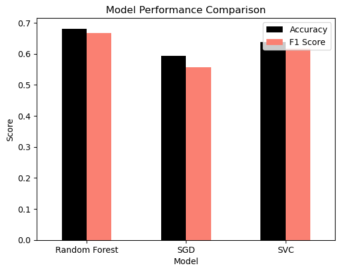

```python
# Store metrics in a dictionary for comparison
model_metrics = {
    'Model': ['Random Forest', 'SGD', 'SVC'],
    'Accuracy': [accuracy_score(y_test, rf_grid_search.predict(X_test)),
                 accuracy_score(y_test, sgd_grid_search.predict(X_test)),
                 accuracy_score(y_test, svc_grid_search.predict(X_test))],
    'F1 Score': [f1_score(y_test, rf_grid_search.predict(X_test), average='weighted'),
                 f1_score(y_test, sgd_grid_search.predict(X_test), average='weighted'),
                 f1_score(y_test, svc_grid_search.predict(X_test), average='weighted')]
}

metrics_df = pd.DataFrame(model_metrics)

# Plot the metrics
plt.figure(figsize=(14, 8))
metrics_df.plot(x='Model', y=['Accuracy', 'F1 Score'], kind='bar', color=['Black', 'salmon'], rot=0)
plt.ylabel('Score')
plt.title('Model Performance Comparison')
plt.legend(loc='upper right')
plt.xticks(np.arange(len(metrics_df['Model'])), metrics_df['Model'])
plt.show()
```

Performance Comparison Bar Chart confirmed the superiority of the Random Forest model.

## 8.3 Final Visualization

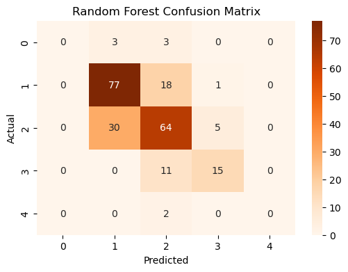

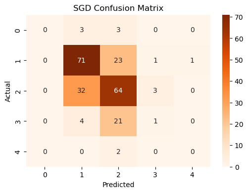

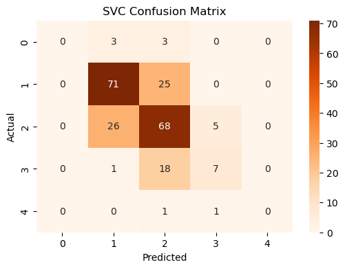

```python
# Plot confusion matrix for each model
for name, model in zip(['Random Forest', 'SGD', 'SVC'], [best_rf_model, sgd_grid_search.best_estimator_, svc_grid_search.best_estimator_]):
    y_pred = model.predict(X_test)
    cm = confusion_matrix(y_test, y_pred)
    plt.figure(figsize=(6, 4))
    sns.heatmap(cm, annot=True, fmt='d', cmap='Oranges')
    plt.xlabel('Predicted')
    plt.ylabel('Actual')
    plt.title(f"{name} Confusion Matrix")
    plt.show()
```

Confusion Matrices provided detailed class-wise performance, showing areas of strength and misclassification.

### 8.4 ROC Curve

```python
from sklearn.metrics import roc_curve, auc
from sklearn.preprocessing import label_binarize
from sklearn.multiclass import OneVsRestClassifier

# For multiclass setup, you could apply OneVsRest strategy (example only if binary/multiclass ROC is needed)
y_bin = label_binarize(y, classes=[3, 4, 5, 6, 7, 8])  # Adjust classes as necessary
X_train_bin, X_test_bin, y_train_bin, y_test_bin = train_test_split(X_scaled, y_bin, test_size=0.2, random_state=42)
```

```python
# Train OneVsRest classifier
ovr_rf = OneVsRestClassifier(best_rf_model)
y_score = ovr_rf.fit(X_train_bin, y_train_bin).predict_proba(X_test_bin)
```

```python
# Compute ROC curve and ROC area for each class
fpr, tpr, roc_auc = {}, {}, {}
for i in range(y_bin.shape[1]):
    fpr[i], tpr[i], _ = roc_curve(y_test_bin[:, i], y_score[:, i])
    roc_auc[i] = auc(fpr[i], tpr[i])
```

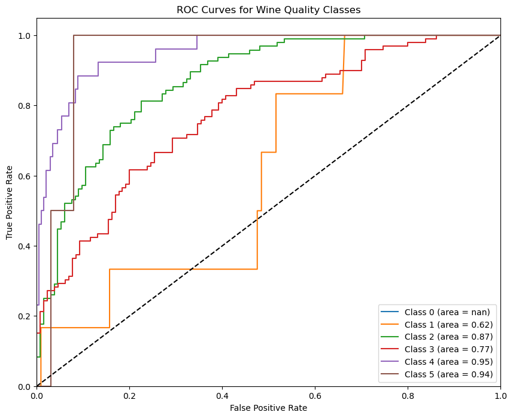

```python
# Plot ROC curves for each class
plt.figure(figsize=(10, 8))
for i in range(y_bin.shape[1]):
    plt.plot(fpr[i], tpr[i], label=f'Class {i} (area = {roc_auc[i]:.2f})')
plt.plot([0, 1], [0, 1], 'k--')
plt.xlim([0.0, 1.0])
plt.ylim([0.0, 1.05])
plt.xlabel('False Positive Rate')
plt.ylabel('True Positive Rate')
plt.title('ROC Curves for Wine Quality Classes')
plt.legend(loc="lower right")
plt.show()
```

# Conclusion

The Wine Quality Prediction project successfully demonstrated the application of machine learning techniques in viticulture. Through meticulous data analysis and model evaluation, the Random Forest Classifier emerged as the most effective tool for predicting wine quality based on chemical attributes. The insights gained from feature importance and model performance not only aid in accurate predictions but also provide valuable information for wine producers aiming to enhance quality. Future work can build upon these findings to further refine predictive models and incorporate a broader range of influencing factors.

-> The `Random Forest` model emerged as the best-performing classifier based on metrics such as accuracy and F1-score. This suggests that Random Forest's ensemble approach is particularly effective for predicting wine quality based on the chemical attributes provided.

-> From feature importance, `Alcohol` and `sulphates` were shown to have the highest influence on quality, implying that these properties play a significant role in determining the wine's perceived quality.

-> The confusion matrix analysis revealed that some quality levels were occasionally misclassified. This is likely due to the subtle differences in chemical composition that make it difficult to distinguish between adjacent quality levels.